# tp0_ej2

```python
from src.catching import attempt_catch
from src.pokemon import PokemonFactory, StatusEffect
import json
import pandas as pd
import matplotlib
import matplotlib.pyplot as plt
import numpy as np
```

```python
pokeballs = ['pokeball','ultraball','fastball','heavyball']
with open('pokemon_clean.json') as f:
    pokes = json.load(f)
factory = PokemonFactory('pokemon_clean.json')
```

Ejercicio 2.a

Analizar el efecto del estado de salud sobre la chance de captura.

```python
aux = []
for pok, detail in pokes.items():
    for status in StatusEffect:
        beast = factory.create(pok,100,status,1)
        for _ in range(2500):
            success, catch_rate = attempt_catch(beast,'pokeball',0)
            aux.append({'pokemon': pok,'statusEffect':status.name, 'pokeball': 'pokeball', 'success': success, 'noise': '0', 'weight': beast.weight, 'speed': beast.stats[-1], 'catch_rate': catch_rate})
df = pd.DataFrame(aux)
df
```

|  | pokemon | statusEffect | pokeball | success | noise | weight | speed | catch_rate |
| --- | --- | --- | --- | --- | --- | --- | --- | --- |
| 0 | jolteon | POISON | pokeball | False | 0 | 54.0 | 130 | 0.0879 |
| 1 | jolteon | POISON | pokeball | False | 0 | 54.0 | 130 | 0.0879 |
| 2 | jolteon | POISON | pokeball | False | 0 | 54.0 | 130 | 0.0879 |
| 3 | jolteon | POISON | pokeball | True | 0 | 54.0 | 130 | 0.0879 |
| 4 | jolteon | POISON | pokeball | True | 0 | 54.0 | 130 | 0.0879 |
| ... | ... | ... | ... | ... | ... | ... | ... | ... |
| 179995 | dragonite | NONE | pokeball | False | 0 | 210.0 | 80 | 0.0586 |
| 179996 | dragonite | NONE | pokeball | False | 0 | 210.0 | 80 | 0.0586 |
| 179997 | dragonite | NONE | pokeball | False | 0 | 210.0 | 80 | 0.0586 |
| 179998 | dragonite | NONE | pokeball | False | 0 | 210.0 | 80 | 0.0586 |
| 179999 | dragonite | NONE | pokeball | False | 0 | 210.0 | 80 | 0.0586 |

180000 rows × 8 columns

```python
probabilidades = df.groupby(['statusEffect'])['success'].mean()
probabilidades
```

```
statusEffect
BURN         0.090100
FREEZE       0.120567
NONE         0.060867
PARALYSIS    0.090667
POISON       0.089967
SLEEP        0.119567
Name: success, dtype: float64
```

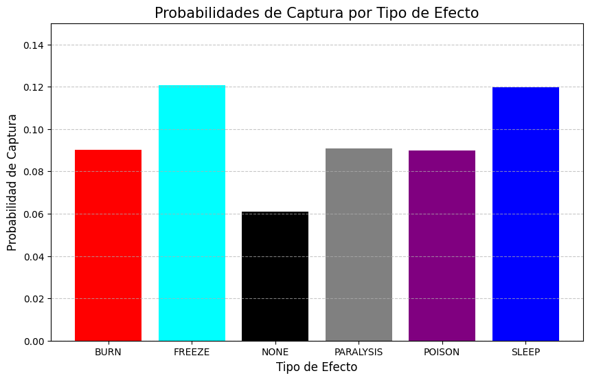

```python
plt.figure(figsize=(10,6))
plt.bar(probabilidades.index.values, probabilidades, color=['red','cyan','black','gray','purple','blue'])
plt.title('Probabilidades de Captura por Tipo de Efecto', fontsize=15)
plt.xlabel('Tipo de Efecto', fontsize=12)
plt.ylabel('Probabilidad de Captura', fontsize=12)
plt.ylim(0, 0.15)
plt.grid(axis='y', linestyle='--', alpha=0.7)
plt.show()
```

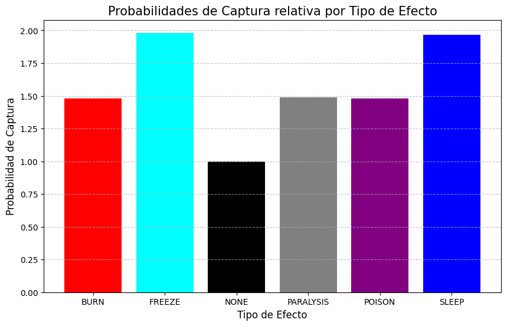

```python
min_prob = min(probabilidades)
probs_rel = [prob / min_prob for prob in probabilidades]
plt.figure(figsize=(10,6))
plt.bar(probabilidades.index.values, probs_rel, color=['red','cyan','black','gray','purple','blue'])
plt.title('Probabilidades de Captura relativa por Tipo de Efecto', fontsize=15)
plt.xlabel('Tipo de Efecto', fontsize=12)
plt.ylabel('Probabilidad de Captura', fontsize=12)
# plt.ylim(0, 0.15)
plt.grid(axis='y', linestyle='--', alpha=0.7)
plt.show()
```

Claramente todos los statusEffects tienen un efecto positivo en la chance de capturar un pokemon. Los mas utiles son FREEZE y SLEEP, ya que duplican la tasa de captura.

Ejercicio 2.b

Analizar el efecto de los puntos de vida sobre la tasa de captura.

```python
aux = []
for pok, detail in pokes.items():
    for life in np.arange(0.01, 1.01, 0.01):
        beast = factory.create(pok,100,StatusEffect.NONE,life) #pokemon con nivel 100 y vida variable
        for _ in range(1000):
            success, catch_rate = attempt_catch(beast,'pokeball',0.05) #attempt_success
            aux.append({'pokemon': pok,'statusEffect':'NONE', 'pokeball': 'pokeball', 'success': success, 'noise': '0.05', 'weight': beast.weight, 'speed': beast.stats[-1],'healthPercentage':life, 'health':beast.current_hp,  'catch_rate': catch_rate})
df2 = pd.DataFrame(aux)
df2
```

|  | pokemon | statusEffect | pokeball | success | noise | weight | speed | healthPercentage | health | catch_rate |
| --- | --- | --- | --- | --- | --- | --- | --- | --- | --- | --- |
| 0 | jolteon | NONE | pokeball | False | 0.05 | 54.0 | 130 | 0.01 | 1 | 0.163189 |
| 1 | jolteon | NONE | pokeball | False | 0.05 | 54.0 | 130 | 0.01 | 1 | 0.176787 |
| 2 | jolteon | NONE | pokeball | True | 0.05 | 54.0 | 130 | 0.01 | 1 | 0.194405 |
| 3 | jolteon | NONE | pokeball | False | 0.05 | 54.0 | 130 | 0.01 | 1 | 0.167067 |
| 4 | jolteon | NONE | pokeball | False | 0.05 | 54.0 | 130 | 0.01 | 1 | 0.175042 |
| ... | ... | ... | ... | ... | ... | ... | ... | ... | ... | ... |
| 1199995 | dragonite | NONE | pokeball | False | 0.05 | 210.0 | 80 | 1.00 | 111 | 0.057562 |
| 1199996 | dragonite | NONE | pokeball | False | 0.05 | 210.0 | 80 | 1.00 | 111 | 0.058576 |
| 1199997 | dragonite | NONE | pokeball | False | 0.05 | 210.0 | 80 | 1.00 | 111 | 0.058548 |
| 1199998 | dragonite | NONE | pokeball | False | 0.05 | 210.0 | 80 | 1.00 | 111 | 0.055482 |
| 1199999 | dragonite | NONE | pokeball | False | 0.05 | 210.0 | 80 | 1.00 | 111 | 0.056924 |

1200000 rows × 10 columns

```python
probs = df2.groupby(['health'])['success'].mean()
probs
```

```
health
1      0.181250
2      0.179583
3      0.173583
4      0.182083
5      0.179167
         ...
109    0.060778
110    0.057600
111    0.061500
112    0.053000
113    0.034000
Name: success, Length: 113, dtype: float64
```

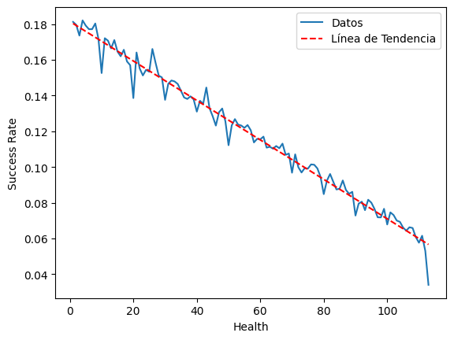

```python
probs = probs.reset_index()

# regresión lineal
z = np.polyfit(probs['health'], probs['success'], 1)
p = np.poly1d(z)

plt.plot(probs['health'],probs['success'], label='Datos')
plt.plot(probs['health'], p(probs['health']), 'r--', label='Línea de Tendencia')

plt.xlabel('Health')
plt.ylabel('Success Rate')
plt.legend()
plt.show()
```

```python
probs_p = df2.groupby(['healthPercentage'])['success'].mean()
probs_p
```

```
healthPercentage
0.01    0.181250
0.02    0.179583
0.03    0.173583
0.04    0.182083
0.05    0.179167
          ...
0.96    0.066167
0.97    0.063750
0.98    0.066667
0.99    0.060750
1.00    0.061250
Name: success, Length: 100, dtype: float64
```

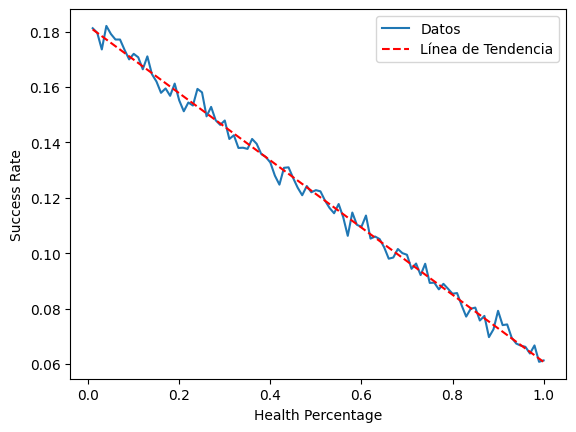

```python
probs_p = probs_p.reset_index()
# regresión lineal
z = np.polyfit(probs_p['healthPercentage'], probs_p['success'], 1)
p = np.poly1d(z)

plt.plot(probs_p['healthPercentage'],probs_p['success'], label='Datos')
plt.plot(probs_p['healthPercentage'], p(probs_p['healthPercentage']), 'r--', label='Línea de Tendencia')

plt.xlabel('Health Percentage')
plt.ylabel('Success Rate')
plt.legend()
plt.show()
```

Se puede observar que es muy claro el efecto de la cantidad de puntos de vida sobre la tasa de captura. Es más claro para el analisis observar las tasas dados porcentajes de vida, ya que parece ser la razon principal del efecto.

Ejercicio 2.c

¿Qué parametros son los que más afectan la tasa de captura?

Como parametros entendemos aquellos que el jugador puede regular en un combate pokemon. Por lo tanto solo vamos a considerar statusEffect y vida del pokemon.

```python
matriz_correlacion_vida = np.corrcoef(probs_p['healthPercentage'], probs_p['success'])
correlacion = matriz_correlacion_vida[0, 1]

print("Correlación vida-captura:", correlacion)
print("Minima tasa captura:", min(probs_p['success']), "\t Maxima tasa captura:", max(probs_p['success']), "\nMaximo multiplier:", max(probs_p['success'])/min(probs_p['success']))
```

```
Correlación vida-captura: -0.9969599250451918
Minima tasa captura: 0.06075 	 Maxima tasa captura: 0.18208333333333335
Maximo multiplier: 2.9972565157750344
```

Del análisis anterior sabemos que los statusEffects pueden a lo sumo tener un efecto x2 en la tasa de captura. Mientras que el porcentaje de vida puede llegar a lo sumo a x3, un numero mucho mayor. Aún asi, en las condiciones de un combate pokemon es muy complicado llegar al punto de vida mínimo deseado (golpes críticos, statusEffects, etc) sin eliminar al contrincante.

Es fácil ver que la mejor estrategia es un statusEffect de alta eficacia como FREEZE o SLEEP, un bajo punto de vida, y la pokebola indicada (Ultraball para la gran mayoria de pokemones, Heavy o Fast para pokemones particularmente pesados o rapidos)

Ejercicio 2.d

Crear la mejor estrategia para un pokemon dado.

Vamos a elegir a Snorlax por su gran peso asi podemos considerar la HeavyBall. Por otro lado vamos a analizar como es la mejor forma de atraparlo.

```python
aux = []
for life in np.arange(0.1, 1.01, 0.1):
    for status in StatusEffect:
        sleepy_boy = factory.create('snorlax', 100, status, life)
        for ball in pokeballs:
            for _ in range(750):
                success, catch_rate = attempt_catch(sleepy_boy,ball,0)
                aux.append({'pokemon': sleepy_boy.name,'statusEffect': status.name, 'pokeball': ball, 'success': success, 'noise': '0', 'weight': sleepy_boy.weight, 'speed': sleepy_boy.stats[-1],'healthPercentage':life, 'health':sleepy_boy.current_hp,  'catch_rate': catch_rate})
df3 = pd.DataFrame(aux)
df3
```

|  | pokemon | statusEffect | pokeball | success | noise | weight | speed | healthPercentage | health | catch_rate |
| --- | --- | --- | --- | --- | --- | --- | --- | --- | --- | --- |
| 0 | snorlax | POISON | pokeball | False | 0 | 1014.1 | 30 | 0.1 | 11 | 0.1370 |
| 1 | snorlax | POISON | pokeball | False | 0 | 1014.1 | 30 | 0.1 | 11 | 0.1370 |
| 2 | snorlax | POISON | pokeball | True | 0 | 1014.1 | 30 | 0.1 | 11 | 0.1370 |
| 3 | snorlax | POISON | pokeball | False | 0 | 1014.1 | 30 | 0.1 | 11 | 0.1370 |
| 4 | snorlax | POISON | pokeball | False | 0 | 1014.1 | 30 | 0.1 | 11 | 0.1370 |
| ... | ... | ... | ... | ... | ... | ... | ... | ... | ... | ... |
| 179995 | snorlax | NONE | heavyball | False | 0 | 1014.1 | 30 | 1.0 | 113 | 0.0846 |
| 179996 | snorlax | NONE | heavyball | False | 0 | 1014.1 | 30 | 1.0 | 113 | 0.0846 |
| 179997 | snorlax | NONE | heavyball | False | 0 | 1014.1 | 30 | 1.0 | 113 | 0.0846 |
| 179998 | snorlax | NONE | heavyball | False | 0 | 1014.1 | 30 | 1.0 | 113 | 0.0846 |
| 179999 | snorlax | NONE | heavyball | False | 0 | 1014.1 | 30 | 1.0 | 113 | 0.0846 |

180000 rows × 10 columns

```python
prob_snor = df3.groupby(['pokeball','healthPercentage'])['success'].mean()
prob_snor
```

```
pokeball   healthPercentage
fastball   0.1                 0.139111
           0.2                 0.138444
           0.3                 0.126667
           0.4                 0.110889
           0.5                 0.105111
           0.6                 0.089778
           0.7                 0.085111
           0.8                 0.078889
           0.9                 0.059778
           1.0                 0.052444
heavyball  0.1                 0.369333
           0.2                 0.348000
           0.3                 0.307556
           0.4                 0.303333
           0.5                 0.270667
           0.6                 0.239778
           0.7                 0.211778
           0.8                 0.196222
           0.9                 0.160000
           1.0                 0.126222
pokeball   0.1                 0.146667
           0.2                 0.141333
           0.3                 0.119333
           0.4                 0.114889
           0.5                 0.104444
           0.6                 0.092444
           0.7                 0.084889
           0.8                 0.071333
           0.9                 0.058000
           1.0                 0.052000
ultraball  0.1                 0.292444
           0.2                 0.268889
           0.3                 0.251556
           0.4                 0.230444
           0.5                 0.206222
           0.6                 0.190000
           0.7                 0.171778
           0.8                 0.150222
           0.9                 0.127778
           1.0                 0.106000
Name: success, dtype: float64
```

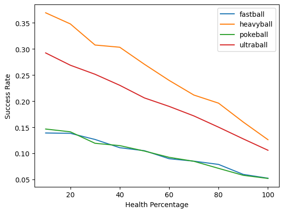

```python
df_reset = prob_snor.reset_index()
pokeballs = df_reset['pokeball'].unique()

for pokeball in pokeballs:
    subset = df_reset[df_reset['pokeball'] == pokeball]
    plt.plot(subset['healthPercentage']*100, subset['success'], label=pokeball)

plt.xlabel('Health Percentage')
plt.ylabel('Success Rate')
plt.legend()
plt.show()
```

Como era de esperarse, la HeavyBall es ideal para capturar a Snorlax. Una UltraBall no es una mala alternativa, pero es clara la ventaja de la HeavyBall.

Ahora analizaremos que statusEffect sera ideal darle a Snorlax para capturarlo, dado los datos anteriores, esperamos que sea FREEZE o SLEEP.

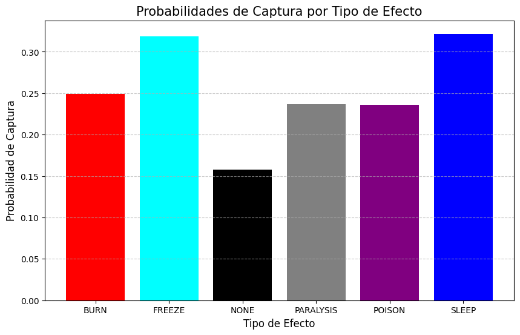

```python
ultra_prob = df3[df3['pokeball'] == 'heavyball']
ultra_effects = ultra_prob.groupby(['statusEffect'])['success'].mean()

plt.figure(figsize=(10,6))
plt.bar(ultra_effects.index.values, ultra_effects, color=['red','cyan','black','gray','purple','blue'])
plt.title('Probabilidades de Captura por Tipo de Efecto', fontsize=15)
plt.xlabel('Tipo de Efecto', fontsize=12)
plt.ylabel('Probabilidad de Captura', fontsize=12)
# plt.ylim(0, 0.15)
plt.grid(axis='y', linestyle='--', alpha=0.7)
plt.show()
```

Una vez mas, gracias a nuestro análisis previo, podemos afirmar con certeza cual es la táctica ideal sin la necesidad de realizar pruebas específicas sobre los pokemones. En este caso, recomendamos SLEEP sobre FREEZE debido a que Snorlax disfruta mucho una siesta.

Por lo tanto, queda finalizada la táctica. Atacar hasta llegar al punto mas bajo posible de HP, inducir SLEEP/FREEZE en Snorlax y utilizar una HeavyBall.

Ejercicio 2.e

Tiene el nivel del pokemon un efecto en la decision de la tactica empleada?

```python
aux = []
for pok, detail in pokes.items():
    for life in np.arange(0.1, 1.01, 0.1):
        for lvl in np.arange(5,100,5):
            for status in StatusEffect:
                beast = factory.create(pok, lvl, status, life)
                for ball in pokeballs:
                    for _ in range(100):
                        success, catch_rate = attempt_catch(beast, ball, 0.05)
                        aux.append({'pokemon': pok,'statusEffect':status.name, 'pokeball': ball, 'success': success, 'noise': '0.05', 'weight': beast.weight, 'speed': beast.stats[-1],'healthPercentage':life, 'health':beast.current_hp, 'level': lvl,  'catch_rate': catch_rate})
df4 = pd.DataFrame(aux)
df4
```

|  | pokemon | statusEffect | pokeball | success | noise | weight | speed | healthPercentage | health | level | catch_rate |
| --- | --- | --- | --- | --- | --- | --- | --- | --- | --- | --- | --- |
| 0 | jolteon | POISON | fastball | True | 0.05 | 54.0 | 130 | 0.1 | 1 | 5 | 1.000000 |
| 1 | jolteon | POISON | fastball | True | 0.05 | 54.0 | 130 | 0.1 | 1 | 5 | 1.000000 |
| 2 | jolteon | POISON | fastball | True | 0.05 | 54.0 | 130 | 0.1 | 1 | 5 | 1.000000 |
| 3 | jolteon | POISON | fastball | True | 0.05 | 54.0 | 130 | 0.1 | 1 | 5 | 0.996408 |
| 4 | jolteon | POISON | fastball | True | 0.05 | 54.0 | 130 | 0.1 | 1 | 5 | 0.984193 |
| ... | ... | ... | ... | ... | ... | ... | ... | ... | ... | ... | ... |
| 5471995 | dragonite | NONE | ultraball | True | 0.05 | 210.0 | 80 | 1.0 | 106 | 95 | 0.124997 |
| 5471996 | dragonite | NONE | ultraball | False | 0.05 | 210.0 | 80 | 1.0 | 106 | 95 | 0.117482 |
| 5471997 | dragonite | NONE | ultraball | False | 0.05 | 210.0 | 80 | 1.0 | 106 | 95 | 0.121373 |
| 5471998 | dragonite | NONE | ultraball | False | 0.05 | 210.0 | 80 | 1.0 | 106 | 95 | 0.120585 |
| 5471999 | dragonite | NONE | ultraball | False | 0.05 | 210.0 | 80 | 1.0 | 106 | 95 | 0.124727 |

5472000 rows × 11 columns

```python
prob_2 = df4.groupby(['level'])['success'].mean()
prob_2
```

```
level
5     0.252309
10    0.251892
15    0.250340
20    0.250382
25    0.249226
30    0.248323
35    0.249358
40    0.248375
45    0.249490
50    0.248316
55    0.247524
60    0.249271
65    0.249083
70    0.247517
75    0.247670
80    0.248927
85    0.247573
90    0.248160
95    0.248462
Name: success, dtype: float64
```

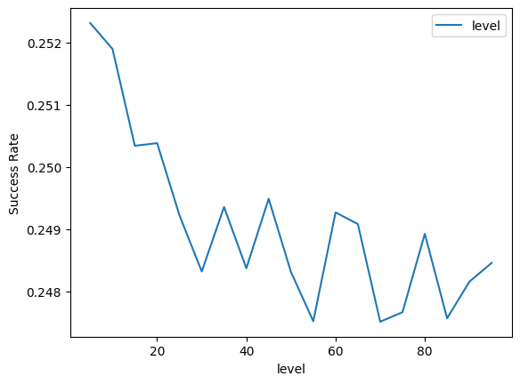

```python
df_reset = prob_2.reset_index()
plt.plot(df_reset['level'],df_reset['success'], label='level')


plt.xlabel('level')
plt.ylabel('Success Rate')
plt.legend()
plt.show()
```

Lo primera observación es que el nivel tiene un efecto extremadamente pequeño en la tasa de exito, tan pequeño que hasta podría considerarse dentro del error.

Para estar seguros vamos a observar si algun punto de vida se ve desproporcionalmente afectado por el nivel.

```python
prob = df4.groupby(['level','healthPercentage'])['success'].mean()
prob
```

```
level  healthPercentage
5      0.1                 0.365139
       0.2                 0.340868
       0.3                 0.323056
       0.4                 0.289792
       0.5                 0.262431
                             ...
95     0.6                 0.233993
       0.7                 0.212951
       0.8                 0.184514
       0.9                 0.163021
       1.0                 0.131285
Name: success, Length: 190, dtype: float64
```

A simple vista el efecto del nivel es muy pequeño.

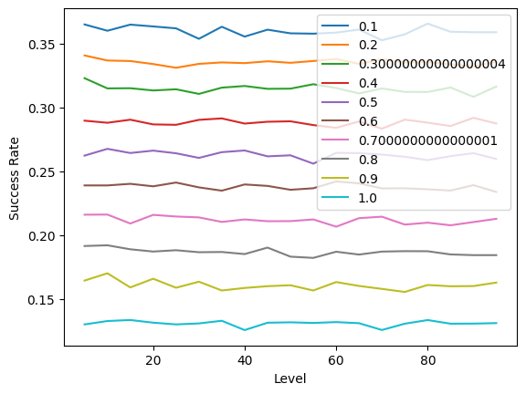

```python
df_reset = prob.reset_index()
effects = df_reset['healthPercentage'].unique()

for effect in effects:
    subset = df_reset[df_reset['healthPercentage'] == effect]
    plt.plot(subset['level'], subset['success'], label=effect)

plt.xlabel('Level')
plt.ylabel('Success Rate')
plt.legend()
plt.show()
```

Ningún punto de vida es desproporcionalmente afectado por el nivel para su tasa de exito. Todos los puntos de vida parecen tener un efecto nulo dado el nivel.

Si observamos las pokebolas y los statusEffects tambien esperamos el mismo resultado.

```python
prob_3 = df4.groupby(['pokeball','level'])['success'].mean()
```

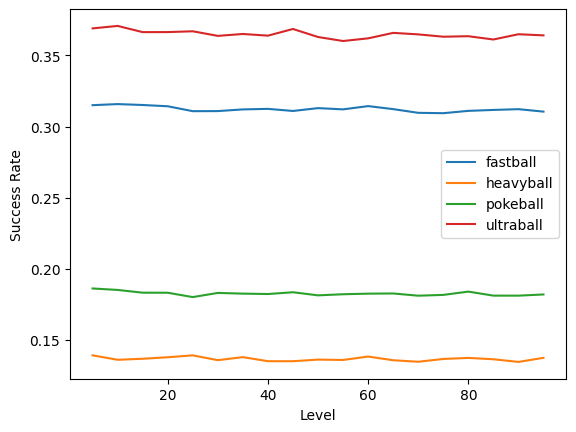

```python
df_reset = prob_3.reset_index()
pokeballs = df_reset['pokeball'].unique()

for pokeball in pokeballs:
    subset = df_reset[df_reset['pokeball'] == pokeball]
    plt.plot(subset['level'], subset['success'], label=pokeball)

plt.xlabel('Level')
plt.ylabel('Success Rate')
plt.legend()
plt.show()
```

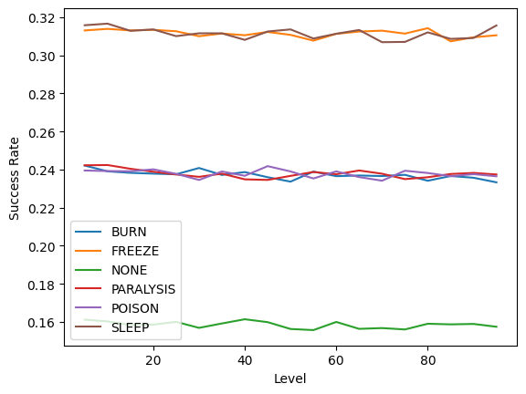

```python
prob_4 = df4.groupby(['statusEffect','level'])['success'].mean()

df_reset = prob_4.reset_index()
pokeballs = df_reset['statusEffect'].unique()

for pokeball in pokeballs:
    subset = df_reset[df_reset['statusEffect'] == pokeball]
    plt.plot(subset['level'], subset['success'], label=pokeball)

plt.xlabel('Level')
plt.ylabel('Success Rate')
plt.legend()
plt.show()
```

Usando este estudio dado todos los pokemones, y la experiencia del inciso anterior donde el estudio de los pokemones en conjunto permite realizar conclusiones sobre tácticas particulares, podemos definir que el nivel no tiene ningún efecto significante sobre la capacidad de capturar un pokemon o la táctica empleada. Por supuesto en una situacion de juego real, un pokemon de alto nivel sera más complejo de llevar a un punto de vida más bajo.